# ¡Hola Rubintel!

## Encuentra y elimina los valores duplicados (y describe cómo tomaste tus decisiones).

### `orders` data frame

```python
# Revisa si hay pedidos duplicados


# Verificar si hay filas duplicadas
duplicados_orders = instacart_orders.duplicated().sum()
print(f"Filas duplicadas en instacart_orders: {duplicados_orders}")

# Mostrar las filas duplicadas
duplicated_rows = instacart_orders[instacart_orders.duplicated()]
print(duplicated_rows)

# Verificar las columnas disponibles
print("Columnas disponibles en duplicated_rows:")
print(duplicated_rows.columns)

# Analizar las filas duplicadas si todas las columnas están presentes
columnas_a_verificar = ['order_id', 'user_id', 'order_number', 'order_dow', 'order_hour_of_day', 'days_since_prior_order']
if set(columnas_a_verificar).issubset(duplicated_rows.columns):
    print(duplicated_rows[columnas_a_verificar].describe(include='all'))
    print(duplicated_rows[columnas_a_verificar])
else:
    print("Una o más de las columnas especificadas no existen en duplicated_rows.")
```

```
Filas duplicadas en instacart_orders: 15
        order_id  user_id  order_number  order_dow  order_hour_of_day  days_since_prior_order
145574    794638    50898            24          3                  2                     2.0
223105   2160484   107525            16          3                  2                    30.0
230807   1918001   188546            14          3                  2                    16.0
266232   1782114   106752             1          3                  2                     NaN
273805   1112182   202304            84          3                  2                     6.0
284038   2845099    31189            11          3                  2                     7.0
311713   1021560    53767             3          3                  2                     9.0
321100    408114    68324             4          3                  2                    18.0
323900   1919531   191501            32          3                  2                     7.0
345917   2232988    82565             1          3                  2                     NaN
371905    391768    57671            19          3                  2                    10.0
394347    467134    63189            21          3                  2                     2.0
411408   1286742   183220            48          3                  2                     4.0
415163   2282673    86751            49          3                  2                     2.0
441599   2125197    14050            48          3                  2                     3.0
Columnas disponibles en duplicated_rows:
Index(['order_id', 'user_id', 'order_number', 'order_dow', 'order_hour_of_day',
       'days_since_prior_order'],
      dtype='object')
           order_id        user_id  order_number  order_dow  order_hour_of_day  days_since_prior_order
count  1.500000e+01      15.000000     15.000000       15.0               15.0               13.000000
mean   1.516548e+06   99216.800000     25.000000        3.0                2.0                8.923077
std    7.847652e+05   62677.205418     23.439893        0.0                0.0                8.149249
min    3.917680e+05   14050.000000      1.000000        3.0                2.0                2.000000
25%    9.080990e+05   55719.000000      7.500000        3.0                2.0                3.000000
50%    1.782114e+06   82565.000000     19.000000        3.0                2.0                7.000000
75%    2.142840e+06  145372.500000     40.000000        3.0                2.0               10.000000
max    2.845099e+06  202304.000000     84.000000        3.0                2.0               30.000000
        order_id  user_id  order_number  order_dow  order_hour_of_day  days_since_prior_order
145574    794638    50898            24          3                  2                     2.0
223105   2160484   107525            16          3                  2                    30.0
230807   1918001   188546            14          3                  2                    16.0
266232   1782114   106752             1          3                  2                     NaN
273805   1112182   202304            84          3                  2                     6.0
284038   2845099    31189            11          3                  2                     7.0
311713   1021560    53767             3          3                  2                     9.0
321100    408114    68324             4          3                  2                    18.0
323900   1919531   191501            32          3                  2                     7.0
345917   2232988    82565             1          3                  2                     NaN
371905    391768    57671            19          3                  2                    10.0
394347    467134    63189            21          3                  2                     2.0
411408   1286742   183220            48          3                  2                     4.0
415163   2282673    86751            49          3                  2                     2.0
441599   2125197    14050            48          3                  2                     3.0
```

¿Tienes líneas duplicadas? Si sí, Tenemos 15 duplicados ¿qué tienen en común? la linea y la hora es la misma en las columnas 4 y 5

```python
# Basándote en tus hallazgos,
# Verifica todos los pedidos que se hicieron el miércoles a las 2:00 a.m.



# Verificar la carga de los datos y mostrar las columnas
print(instacart_orders.head())
print("Columnas disponibles en instacart_orders:")
print(instacart_orders.columns)

# Filtrar pedidos hechos el miércoles (order_dow = 3) a las 2:00 a.m. (order_hour_of_day == 2)
if 'order_dow' in instacart_orders.columns and 'order_hour_of_day' in instacart_orders.columns:
    pedidos_miercoles_2am = instacart_orders[(instacart_orders['order_dow'] == 3) & (instacart_orders['order_hour_of_day'] == 2)]

    # Mostrar los pedidos filtrados
    print(pedidos_miercoles_2am)

    # Describir los pedidos filtrados
    print(pedidos_miercoles_2am.describe(include='all'))

    # Mostrar los primeros y últimos 5 registros para revisión
    print(pedidos_miercoles_2am.head())
    print(pedidos_miercoles_2am.tail())
else:
    print("Las columnas 'order_dow' y 'order_hour_of_day' no están presentes en el DataFrame.")
```

```
   order_id  user_id  order_number  order_dow  order_hour_of_day  days_since_prior_order
0   1515936   183418            11          6                 13                    30.0
1   1690866   163593             5          5                 12                     9.0
2   1454967    39980             4          5                 19                     2.0
3   1768857    82516            56          0                 20                    10.0
4   3007858   196724             2          4                 12                    17.0
Columnas disponibles en instacart_orders:
Index(['order_id', 'user_id', 'order_number', 'order_dow', 'order_hour_of_day',
       'days_since_prior_order'],
      dtype='object')
        order_id  user_id  order_number  order_dow  order_hour_of_day  days_since_prior_order
4838     2766110   162084            41          3                  2                    16.0
5156     2190225   138285            18          3                  2                    11.0
15506     553049    58599            13          3                  2                     7.0
18420     382357   120200            19          3                  2                    11.0
24691     690242    77357             2          3                  2                     9.0
...          ...      ...           ...        ...                ...                     ...
457013   3384021    14881             6          3                  2                    30.0
458816    910166   164782            18          3                  2                     4.0
459635   1680532   106435             6          3                  2                    21.0
468324    222962    54979            59          3                  2                     3.0
477526   2592344    46860            38          3                  2                     3.0

[121 rows x 6 columns]
           order_id        user_id  order_number  order_dow  order_hour_of_day  days_since_prior_order
count  1.210000e+02     121.000000    121.000000      121.0              121.0               114.00000
mean   1.559747e+06   97662.173554     17.190083        3.0                2.0                12.54386
std    9.295876e+05   58662.258670     18.266688        0.0                0.0                 9.85123
min    1.910000e+02    3510.000000      1.000000        3.0                2.0                 1.00000
25%    7.369830e+05   50898.000000      5.000000        3.0                2.0                 4.25000
50%    1.496645e+06   85622.000000     10.000000        3.0                2.0                 9.00000
75%    2.282673e+06  144464.000000     24.000000        3.0                2.0                18.75000
max    3.389820e+06  204961.000000     96.000000        3.0                2.0                30.00000
       order_id  user_id  order_number  order_dow  order_hour_of_day  days_since_prior_order
4838    2766110   162084            41          3                  2                    16.0
5156    2190225   138285            18          3                  2                    11.0
15506    553049    58599            13          3                  2                     7.0
18420    382357   120200            19          3                  2                    11.0
24691    690242    77357             2          3                  2                     9.0
        order_id  user_id  order_number  order_dow  order_hour_of_day  days_since_prior_order
457013   3384021    14881             6          3                  2                    30.0
458816    910166   164782            18          3                  2                     4.0
459635   1680532   106435             6          3                  2                    21.0
468324    222962    54979            59          3                  2                     3.0
477526   2592344    46860            38          3                  2                     3.0
```

```python
# Elimina los pedidos duplicados



# Verificar la carga de los datos y mostrar las columnas
print(instacart_orders.head())
print("Columnas disponibles en instacart_orders:")
print(instacart_orders.columns)

# Mostrar las filas duplicadas recordar que estos valores se eliminaran por ser dupicados explícitos
duplicated_rows = instacart_orders[instacart_orders.duplicated()]
print(duplicated_rows)

# Paso 1: Eliminar duplicados explícitos
instacart_orders_explicit_dedup = instacart_orders.drop_duplicates()
print(f"Filas después de eliminar duplicados explícitos: {instacart_orders_explicit_dedup.shape[0]}")

# Paso 2: Identificar duplicados implícitos basados en 'order_id' esto es importante ya que solo estamos verificando un solo tipo de duplicados
duplicated_order_ids = instacart_orders_explicit_dedup[instacart_orders_explicit_dedup.duplicated('order_id', keep=False)]
print(f"Duplicados implícitos identificados (por 'order_id'): {duplicated_order_ids.shape[0]}")

# Verificar las filas con 'order_id' duplicado
print(duplicated_order_ids.sort_values('order_id'))
```

```
   order_id  user_id  order_number  order_dow  order_hour_of_day  days_since_prior_order
0   1515936   183418            11          6                 13                    30.0
1   1690866   163593             5          5                 12                     9.0
2   1454967    39980             4          5                 19                     2.0
3   1768857    82516            56          0                 20                    10.0
4   3007858   196724             2          4                 12                    17.0
Columnas disponibles en instacart_orders:
Index(['order_id', 'user_id', 'order_number', 'order_dow', 'order_hour_of_day',
       'days_since_prior_order'],
      dtype='object')
        order_id  user_id  order_number  order_dow  order_hour_of_day  days_since_prior_order
145574    794638    50898            24          3                  2                     2.0
223105   2160484   107525            16          3                  2                    30.0
230807   1918001   188546            14          3                  2                    16.0
266232   1782114   106752             1          3                  2                     NaN
273805   1112182   202304            84          3                  2                     6.0
284038   2845099    31189            11          3                  2                     7.0
311713   1021560    53767             3          3                  2                     9.0
321100    408114    68324             4          3                  2                    18.0
323900   1919531   191501            32          3                  2                     7.0
345917   2232988    82565             1          3                  2                     NaN
371905    391768    57671            19          3                  2                    10.0
394347    467134    63189            21          3                  2                     2.0
411408   1286742   183220            48          3                  2                     4.0
415163   2282673    86751            49          3                  2                     2.0
441599   2125197    14050            48          3                  2                     3.0
Filas después de eliminar duplicados explícitos: 478952
Duplicados implícitos identificados (por 'order_id'): 0
Empty DataFrame
Columns: [order_id, user_id, order_number, order_dow, order_hour_of_day, days_since_prior_order]
Index: []
```

```python
# Vuelve a verificar si hay filas duplicadas



# Verificar la carga de los datos y mostrar las columnas
print(instacart_orders.head())
print("Columnas disponibles en instacart_orders:")
print(instacart_orders.columns)

# Paso 1: Eliminar duplicados explícitos
instacart_orders_explicit_dedup = instacart_orders.drop_duplicates()
print(f"Filas después de eliminar duplicados explícitos: {instacart_orders_explicit_dedup.shape[0]}")

# Paso 2: Identificar duplicados implícitos basados en 'order_id'
duplicated_order_ids = instacart_orders_explicit_dedup[instacart_orders_explicit_dedup.duplicated('order_id', keep=False)]
print(f"Duplicados implícitos identificados (por 'order_id'): {duplicated_order_ids.shape[0]}")

# Mostrar las filas con 'order_id' duplicado
print(duplicated_order_ids.sort_values('order_id'))

# Eliminar duplicados basados en 'order_id', manteniendo solo la primera aparición
instacart_orders_dedup = instacart_orders_explicit_dedup.drop_duplicates(subset='order_id', keep='first')
print(f"Filas después de eliminar duplicados por 'order_id': {instacart_orders_dedup.shape[0]}")

# Vuelve a verificar únicamente si hay IDs duplicados de pedidos

# Verificar si hay duplicados en la columna 'order_id'
duplicated_order_ids_after = instacart_orders_dedup[instacart_orders_dedup.duplicated('order_id', keep=False)]
print(f"Número de IDs de pedidos duplicados después de la eliminación: {duplicated_order_ids_after.shape[0]}")

# Mostrar las filas con 'order_id' duplicado después de la eliminación
print(duplicated_order_ids_after.sort_values('order_id'))

# Mostrar algunas filas finales para verificación
print(instacart_orders_dedup.head())
print(instacart_orders_dedup.tail())
```

```
   order_id  user_id  order_number  order_dow  order_hour_of_day  days_since_prior_order
0   1515936   183418            11          6                 13                    30.0
1   1690866   163593             5          5                 12                     9.0
2   1454967    39980             4          5                 19                     2.0
3   1768857    82516            56          0                 20                    10.0
4   3007858   196724             2          4                 12                    17.0
Columnas disponibles en instacart_orders:
Index(['order_id', 'user_id', 'order_number', 'order_dow', 'order_hour_of_day',
       'days_since_prior_order'],
      dtype='object')
Filas después de eliminar duplicados explícitos: 478952
Duplicados implícitos identificados (por 'order_id'): 0
Empty DataFrame
Columns: [order_id, user_id, order_number, order_dow, order_hour_of_day, days_since_prior_order]
Index: []
Filas después de eliminar duplicados por 'order_id': 478952
Número de IDs de pedidos duplicados después de la eliminación: 0
Empty DataFrame
Columns: [order_id, user_id, order_number, order_dow, order_hour_of_day, days_since_prior_order]
Index: []
   order_id  user_id  order_number  order_dow  order_hour_of_day  days_since_prior_order
0   1515936   183418            11          6                 13                    30.0
1   1690866   163593             5          5                 12                     9.0
2   1454967    39980             4          5                 19                     2.0
3   1768857    82516            56          0                 20                    10.0
4   3007858   196724             2          4                 12                    17.0
        order_id  user_id  order_number  order_dow  order_hour_of_day  days_since_prior_order
478962   3210681     5617             5          1                 14                     7.0
478963   3270802   112087             2          3                 13                     6.0
478964    885349    82944            16          2                 11                     6.0
478965    216274     4391             3          3                  8                     8.0
478966   2071924     1730            18          1                 14                    15.0
```

```python
# Vuelve a verificar únicamente si hay IDs duplicados de pedidos


# Verificar la carga de los datos y mostrar las columnas
print(instacart_orders_explicit_dedup.head())
print("Columnas disponibles en instacart_orders_explicit_dedup:")
print(instacart_orders_explicit_dedup.columns)

# Verificar si hay duplicados en la columna 'order_id'
duplicated_order_ids = instacart_orders_explicit_dedup[instacart_orders_explicit_dedup.duplicated('order_id', keep=False)]
print(f"Número de IDs de pedidos duplicados: {duplicated_order_ids.shape[0]}")

# Mostrar las filas con 'order_id' duplicado
print(duplicated_order_ids.sort_values('order_id'))
```

```
   order_id  user_id  order_number  order_dow  order_hour_of_day  days_since_prior_order
0   1515936   183418            11          6                 13                    30.0
1   1690866   163593             5          5                 12                     9.0
2   1454967    39980             4          5                 19                     2.0
3   1768857    82516            56          0                 20                    10.0
4   3007858   196724             2          4                 12                    17.0
Columnas disponibles en instacart_orders_explicit_dedup:
Index(['order_id', 'user_id', 'order_number', 'order_dow', 'order_hour_of_day',
       'days_since_prior_order'],
      dtype='object')
Número de IDs de pedidos duplicados: 0
Empty DataFrame
Columns: [order_id, user_id, order_number, order_dow, order_hour_of_day, days_since_prior_order]
Index: []
```

Describe brevemente tus hallazgos y lo que hiciste con ellos

**Comentario del revisor**

Perfecto.

### `products` data frame

```python
# Verifica si hay filas totalmente duplicadas



# Verificar la carga de los datos y mostrar las primeras filas
print(products.head())
print("Columnas disponibles en products:")
print(products.columns)

# Verificar si hay filas totalmente duplicadas
duplicados_products = products.duplicated().sum()
print(f"Filas totalmente duplicadas en products: {duplicados_products}")

##Eliminarlos productos duplicados usando drop_duplicates()
#products = products.drop_duplicates()
#print(f"Filas después de eliminar duplicados: {products.shape[0]}")

# Mostrar las filas duplicadas
duplicated_rows_products = products[products.duplicated()]
print(duplicated_rows_products)
```

```
   product_id                                       product_name  aisle_id  department_id
0           1                         Chocolate Sandwich Cookies        61             19
1           2                                   All-Seasons Salt       104             13
2           3               Robust Golden Unsweetened Oolong Tea        94              7
3           4  Smart Ones Classic Favorites Mini Rigatoni Wit...        38              1
4           5                          Green Chile Anytime Sauce         5             13
Columnas disponibles en products:
Index(['product_id', 'product_name', 'aisle_id', 'department_id'], dtype='object')
Filas totalmente duplicadas en products: 0
Empty DataFrame
Columns: [product_id, product_name, aisle_id, department_id]
Index: []
```

```python
# Revisa únicamente si hay nombres duplicados de productos (convierte los nombres a letras mayúsculas para compararlos mejor)


# Verificar la carga de los datos y mostrar las primeras filas
print(products.head())
print("Columnas disponibles en products:")
print(products.columns)

# Convertir los nombres de los productos a letras mayúsculas para comparación uniforme
products['product_name_upper'] = products['product_name'].str.upper()

# Verificar si hay nombres duplicados de productos en la columna 'product_name_upper'
duplicated_product_names = products[products.duplicated('product_name_upper', keep=False)]
print(f"Número de nombres de productos duplicados: {duplicated_product_names['product_name_upper'].nunique()}")

# Mostrar las filas con 'product_name_upper' duplicado
print(duplicated_product_names.sort_values('product_name_upper'))
```

```
   product_id                                       product_name  aisle_id  department_id
0           1                         Chocolate Sandwich Cookies        61             19
1           2                                   All-Seasons Salt       104             13
2           3               Robust Golden Unsweetened Oolong Tea        94              7
3           4  Smart Ones Classic Favorites Mini Rigatoni Wit...        38              1
4           5                          Green Chile Anytime Sauce         5             13
Columnas disponibles en products:
Index(['product_id', 'product_name', 'aisle_id', 'department_id'], dtype='object')
Número de nombres de productos duplicados: 103
       product_id                               product_name  aisle_id  department_id                         product_name_upper
23339       23340  18-in-1 Hemp Peppermint Pure-Castile Soap        25             11  18-IN-1 HEMP PEPPERMINT PURE-CASTILE SOAP
31844       31845  18-In-1 Hemp Peppermint Pure-Castile Soap        25             11  18-IN-1 HEMP PEPPERMINT PURE-CASTILE SOAP
19941       19942            Aged Balsamic Vinegar Of Modena        19             13            AGED BALSAMIC VINEGAR OF MODENA
13152       13153            Aged Balsamic Vinegar of Modena        19             13            AGED BALSAMIC VINEGAR OF MODENA
24830       24831         Albacore Solid White Tuna in Water        95             15         ALBACORE SOLID WHITE TUNA IN WATER
...           ...                                        ...       ...            ...                                        ...
49552       49553                                        NaN       100             21                                        NaN
49574       49575                                        NaN       100             21                                        NaN
49640       49641                                        NaN       100             21                                        NaN
49663       49664                                        NaN       100             21                                        NaN
49668       49669                                        NaN       100             21                                        NaN

[1465 rows x 5 columns]
```

```python
# Revisa si hay nombres duplicados de productos no faltantes

#Aqui integro todas las solciones y casos que podemos encontrar

# Verificar si hay filas totalmente duplicadas
duplicados_products = products.duplicated().sum()
print(f"Filas totalmente duplicadas en products: {duplicados_products}")

# Mostrar las filas duplicadas
duplicated_rows_products = products[products.duplicated()]
print(duplicated_rows_products)

# Eliminar productos duplicados usando drop_duplicates() y mostrar el número de filas
products = products.drop_duplicates()
print(f"Filas después de eliminar duplicados: {products.shape[0]}")

# Convertir los nombres de los productos a letras mayúsculas para comparación uniforme
products['product_name_upper'] = products['product_name'].str.upper()

# Verificar si hay nombres duplicados de productos en la columna 'product_name_upper'
duplicated_product_names = products[products.duplicated('product_name_upper', keep=False)]
print(f"Número de nombres de productos duplicados: {duplicated_product_names['product_name_upper'].nunique()}")

# Mostrar las filas con 'product_name_upper' duplicado
print(duplicated_product_names.sort_values('product_name_upper'))

# Eliminar duplicados manteniendo solo la primera aparición
products = products.drop_duplicates(subset='product_name_upper', keep='first')
print(f"Filas después de eliminar nombres duplicados: {products.shape[0]}")

# Eliminar filas donde 'product_name' es NaN
products_non_missing = products.dropna(subset=['product_name'])

# Verificar si hay nombres duplicados de productos en la columna 'product_name_upper'
duplicated_product_names = products_non_missing[products_non_missing.duplicated('product_name_upper', keep=False)]
print(f"Número de nombres de productos duplicados (no faltantes): {duplicated_product_names['product_name_upper'].nunique()}")

# Mostrar las filas con 'product_name_upper' duplicado
print(duplicated_product_names.sort_values('product_name_upper'))

# Eliminar duplicados manteniendo solo la primera aparición en productos no faltantes
products_non_missing = products_non_missing.drop_duplicates(subset='product_name_upper', keep='first')
print(f"Filas después de eliminar nombres duplicados (no faltantes): {products_non_missing.shape[0]}")
```

```
Filas totalmente duplicadas en products: 0
Empty DataFrame
Columns: [product_id, product_name, aisle_id, department_id, product_name_upper]
Index: []
Filas después de eliminar duplicados: 49694
Número de nombres de productos duplicados: 103
       product_id                               product_name  aisle_id  department_id                         product_name_upper
23339       23340  18-in-1 Hemp Peppermint Pure-Castile Soap        25             11  18-IN-1 HEMP PEPPERMINT PURE-CASTILE SOAP
31844       31845  18-In-1 Hemp Peppermint Pure-Castile Soap        25             11  18-IN-1 HEMP PEPPERMINT PURE-CASTILE SOAP
19941       19942            Aged Balsamic Vinegar Of Modena        19             13            AGED BALSAMIC VINEGAR OF MODENA
13152       13153            Aged Balsamic Vinegar of Modena        19             13            AGED BALSAMIC VINEGAR OF MODENA
24830       24831         Albacore Solid White Tuna in Water        95             15         ALBACORE SOLID WHITE TUNA IN WATER
...           ...                                        ...       ...            ...                                        ...
49552       49553                                        NaN       100             21                                        NaN
49574       49575                                        NaN       100             21                                        NaN
49640       49641                                        NaN       100             21                                        NaN
49663       49664                                        NaN       100             21                                        NaN
49668       49669                                        NaN       100             21                                        NaN

[1465 rows x 5 columns]
Filas después de eliminar nombres duplicados: 48333
Número de nombres de productos duplicados (no faltantes): 0
Empty DataFrame
Columns: [product_id, product_name, aisle_id, department_id, product_name_upper]
Index: []
Filas después de eliminar nombres duplicados (no faltantes): 48332
```

Describe brevemente tus hallazgos y lo que hiciste con ellos.

A) Filas Totalmente Duplicadas: No se encontraron filas totalmente duplicadas en el DataFrame products, lo que sugiere que todas las filas son únicas considerando todas las columnas.

B) Nombres Duplicados de Productos: Se encontraron 103 nombres de productos duplicados cuando se convirtieron a letras mayúsculas. Esto indica que hay productos con nombres similares que podrían ser redundantes.

E) Se encontraron 103 nombres de productos duplicados cuando se convirtieron a letras mayúsculas.

**Comentario del revisor**

Muy bien.

### `departments` data frame

```python
# Revisa si hay filas totalmente duplicadas



# Verificar la carga de los datos y mostrar las primeras filas
print(departments.head())
print("Columnas disponibles en departments:")
print(departments.columns)

# Verificar si hay filas totalmente duplicadas
duplicados_departments = departments.duplicated().sum()
print(f"Filas totalmente duplicadas en departments: {duplicados_departments}")

# Mostrar las filas duplicadas
duplicated_rows_departments = departments[departments.duplicated()]
print(duplicated_rows_departments)

# Eliminar departamentos duplicados usando drop_duplicates() y mostrar el número de filas
departments = departments.drop_duplicates()
print(f"Filas después de eliminar duplicados: {departments.shape[0]}")
```

```
   department_id department
0              1     frozen
1              2      other
2              3     bakery
3              4    produce
4              5    alcohol
Columnas disponibles en departments:
Index(['department_id', 'department'], dtype='object')
Filas totalmente duplicadas en departments: 0
Empty DataFrame
Columns: [department_id, department]
Index: []
Filas después de eliminar duplicados: 21
```

```python
# Revisa únicamente si hay IDs duplicadas de productos


# Verificar la carga de los datos y mostrar las primeras filas
print(departments.head())
print("Columnas disponibles en departments:")
print(departments.columns)

# Verificar si hay IDs de departamentos duplicados en la columna 'department_id'
duplicated_department_ids = departments[departments.duplicated('department_id', keep=False)]
print(f"Número de IDs de departamentos duplicados: {duplicated_department_ids['department_id'].nunique()}")

# Mostrar las filas con 'department_id' duplicado
print(duplicated_department_ids.sort_values('department_id'))
```

```
   department_id department
0              1     frozen
1              2      other
2              3     bakery
3              4    produce
4              5    alcohol
Columnas disponibles en departments:
Index(['department_id', 'department'], dtype='object')
Número de IDs de departamentos duplicados: 0
Empty DataFrame
Columns: [department_id, department]
Index: []
```

Describe brevemente tus hallazgos y lo que hiciste con ellos.

A) No se encontraron filas totalmente duplicadas en el DataFrame departments.

B) La eliminación de duplicados confirmó que todas las filas son únicas, y el número de filas se mantuvo en 21, lo que confirma que cada department_id es único.

### `aisles` data frame

```python
# Revisa si hay filas totalmente duplicadas



# Verificar la carga de los datos y mostrar las primeras filas
print(aisles.head())
print("Columnas disponibles en aisles:")
print(aisles.columns)

# Verificar si hay filas totalmente duplicadas
duplicados_aisles = aisles.duplicated().sum()
print(f"Filas totalmente duplicadas en aisles: {duplicados_aisles}")

# Mostrar las filas duplicadas
duplicated_rows_aisles = aisles[aisles.duplicated()]
print(duplicated_rows_aisles)

# Eliminar filas duplicadas usando drop_duplicates() y mostrar el número de filas
aisles = aisles.drop_duplicates()
print(f"Filas después de eliminar duplicados: {aisles.shape[0]}")
```

```
   aisle_id                       aisle
0         1       prepared soups salads
1         2           specialty cheeses
2         3         energy granola bars
3         4               instant foods
4         5  marinades meat preparation
Columnas disponibles en aisles:
Index(['aisle_id', 'aisle'], dtype='object')
Filas totalmente duplicadas en aisles: 0
Empty DataFrame
Columns: [aisle_id, aisle]
Index: []
Filas después de eliminar duplicados: 134
```

```python
# Revisa únicamente si hay IDs duplicadas de productos



# Verificar la carga de los datos y mostrar las primeras filas
print(aisles.head())
print("Columnas disponibles en aisles:")
print(aisles.columns)

# Verificar si hay IDs de pasillos duplicados en la columna 'aisle_id'
duplicated_aisle_ids = aisles[aisles.duplicated('aisle_id', keep=False)]
print(f"Número de IDs de pasillos duplicados: {duplicated_aisle_ids['aisle_id'].nunique()}")

# Mostrar las filas con 'aisle_id' duplicado
print(duplicated_aisle_ids.sort_values('aisle_id'))
```

```
   aisle_id                       aisle
0         1       prepared soups salads
1         2           specialty cheeses
2         3         energy granola bars
3         4               instant foods
4         5  marinades meat preparation
Columnas disponibles en aisles:
Index(['aisle_id', 'aisle'], dtype='object')
Número de IDs de pasillos duplicados: 0
Empty DataFrame
Columns: [aisle_id, aisle]
Index: []
```

Describe brevemente tus hallazgos y lo que hiciste con ellos.

A) No se encontraron filas totalmente duplicadas en el DataFrame aisles.

B) No se encontraron IDs de pasillos duplicados, lo que confirma que cada aisle_id es único.

C) No se requieren acciones adicionales ya que no se encontraron duplicados en las filas ni en los IDs de los pasillos.

### `order_products` data frame

```python
# Revisa si hay filas totalmente duplicadas


# Verificar la carga de los datos y mostrar las primeras filas
print(order_products.head())
print("Columnas disponibles en order_products:")
print(order_products.columns)

# Verificar si hay filas totalmente duplicadas
duplicados_order_products = order_products.duplicated().sum()
print(f"Filas totalmente duplicadas en order_products: {duplicados_order_products}")

# Mostrar las filas duplicadas
duplicated_rows_order_products = order_products[order_products.duplicated()]
print(duplicated_rows_order_products)

# Eliminar filas duplicadas usando drop_duplicates() y mostrar el número de filas
order_products = order_products.drop_duplicates()
print(f"Filas después de eliminar duplicados: {order_products.shape[0]}")
```

```
   order_id  product_id  add_to_cart_order  reordered
0   2141543       11440               17.0          0
1    567889        1560                1.0          1
2   2261212       26683                1.0          1
3    491251        8670               35.0          1
4   2571142        1940                5.0          1
Columnas disponibles en order_products:
Index(['order_id', 'product_id', 'add_to_cart_order', 'reordered'], dtype='object')
Filas totalmente duplicadas en order_products: 0
Empty DataFrame
Columns: [order_id, product_id, add_to_cart_order, reordered]
Index: []
Filas después de eliminar duplicados: 4545007
```

```python
# Vuelve a verificar si hay cualquier otro duplicado engañoso


# Verificar la carga de los datos y mostrar las primeras filas
print(order_products.head())
print("Columnas disponibles en order_products:")
print(order_products.columns)

# Paso 1: Verificar y Eliminar Duplicados Explícitos
duplicados_explicitos = order_products.duplicated().sum()
print(f"Filas totalmente duplicadas en order_products: {duplicados_explicitos}")

# Mostrar las filas duplicadas explícitas
duplicated_rows_explicitos = order_products[order_products.duplicated()]
print(duplicated_rows_explicitos)

# Eliminar duplicados explícitos usando drop_duplicates() y mostrar el número de filas
order_products = order_products.drop_duplicates()
print(f"Filas después de eliminar duplicados explícitos: {order_products.shape[0]}")
```

```
   order_id  product_id  add_to_cart_order  reordered
0   2141543       11440               17.0          0
1    567889        1560                1.0          1
2   2261212       26683                1.0          1
3    491251        8670               35.0          1
4   2571142        1940                5.0          1
Columnas disponibles en order_products:
Index(['order_id', 'product_id', 'add_to_cart_order', 'reordered'], dtype='object')
Filas totalmente duplicadas en order_products: 0
Empty DataFrame
Columns: [order_id, product_id, add_to_cart_order, reordered]
Index: []
Filas después de eliminar duplicados explícitos: 4545007
```

Describe brevemente tus hallazgos y lo que hiciste con ellos.

A) No se encontraron filas totalmente duplicadas en el DataFrame order_products.

**Comentario del revisor**

Esta seccion esta perfecta.

## Encuentra y elimina los valores ausentes

Al trabajar con valores duplicados, pudimos observar que también nos falta investigar valores ausentes:

- La columna `'product_name'` de la tabla products.
- La columna `'days_since_prior_order'` de la tabla orders.
- La columna `'add_to_cart_order'` de la tabla order_productos.

### `products` data frame

```python
# Encuentra los valores ausentes en la columna 'product_name'



# Verificar la carga de los datos y mostrar las primeras filas
print(products.head())
print("Columnas disponibles en products:")
print(products.columns)

# Verificar valores ausentes en la columna 'product_name'
missing_product_name = products['product_name'].isnull().sum()
print(f"Número de valores ausentes en 'product_name': {missing_product_name}")

# Mostrar las filas con valores ausentes en 'product_name'
missing_product_name_rows = products[products['product_name'].isnull()]
print(missing_product_name_rows)
```

```
   product_id                                       product_name  aisle_id  department_id                                 product_name_upper
0           1                         Chocolate Sandwich Cookies        61             19                         CHOCOLATE SANDWICH COOKIES
1           2                                   All-Seasons Salt       104             13                                   ALL-SEASONS SALT
2           3               Robust Golden Unsweetened Oolong Tea        94              7               ROBUST GOLDEN UNSWEETENED OOLONG TEA
3           4  Smart Ones Classic Favorites Mini Rigatoni Wit...        38              1  SMART ONES CLASSIC FAVORITES MINI RIGATONI WIT...
4           5                          Green Chile Anytime Sauce         5             13                          GREEN CHILE ANYTIME SAUCE
Columnas disponibles en products:
Index(['product_id', 'product_name', 'aisle_id', 'department_id',
       'product_name_upper'],
      dtype='object')
Número de valores ausentes en 'product_name': 1
    product_id product_name  aisle_id  department_id product_name_upper
37          38          NaN       100             21                NaN
```

Describe brevemente cuáles son tus hallazgos.

A) Se encontró 1 valor ausente en la columna product_name del DataFrame products.

B) Producto ausente "se imprimió esta información " product_id: 38 aisle_id: 100 department_id: 21 product_name: NaN product_name_upper: NaN

```python
#  ¿Todos los nombres de productos ausentes están relacionados con el pasillo con ID 100?


# Verificar la carga de los datos y mostrar las primeras filas
print(products.head())
print("Columnas disponibles en products:")
print(products.columns)

# Filtrar filas con valores ausentes en 'product_name'
missing_product_name_rows = products[products['product_name'].isnull()]

# Verificar si todos los nombres de productos ausentes están relacionados con el pasillo con ID 100
all_missing_related_to_aisle_100 = missing_product_name_rows['aisle_id'].eq(100).all()
print(f"¿Todos los nombres de productos ausentes están relacionados con el pasillo con ID 100?: {all_missing_related_to_aisle_100}")

# Mostrar las filas con valores ausentes en 'product_name'
print(missing_product_name_rows)
```

```
   product_id                                       product_name  aisle_id  department_id                                 product_name_upper
0           1                         Chocolate Sandwich Cookies        61             19                         CHOCOLATE SANDWICH COOKIES
1           2                                   All-Seasons Salt       104             13                                   ALL-SEASONS SALT
2           3               Robust Golden Unsweetened Oolong Tea        94              7               ROBUST GOLDEN UNSWEETENED OOLONG TEA
3           4  Smart Ones Classic Favorites Mini Rigatoni Wit...        38              1  SMART ONES CLASSIC FAVORITES MINI RIGATONI WIT...
4           5                          Green Chile Anytime Sauce         5             13                          GREEN CHILE ANYTIME SAUCE
Columnas disponibles en products:
Index(['product_id', 'product_name', 'aisle_id', 'department_id',
       'product_name_upper'],
      dtype='object')
¿Todos los nombres de productos ausentes están relacionados con el pasillo con ID 100?: True
    product_id product_name  aisle_id  department_id product_name_upper
37          38          NaN       100             21                NaN
```

Describe brevemente cuáles son tus hallazgos.

A) Todos los nombres de productos ausentes en la columna product_name están relacionados con el pasillo con ID 100.

```python
# ¿Todos los nombres de productos ausentes están relacionados con el departamento con ID 21?



# Verificar la carga de los datos y mostrar las primeras filas
print(products.head())
print("Columnas disponibles en products:")
print(products.columns)

# Filtrar filas con valores ausentes en 'product_name'
missing_product_name_rows = products[products['product_name'].isnull()]

# Verificar si todos los nombres de productos ausentes están relacionados con el departamento con ID 21
all_missing_related_to_department_21 = missing_product_name_rows['department_id'].eq(21).all()
print(f"¿Todos los nombres de productos ausentes están relacionados con el departamento con ID 21?: {all_missing_related_to_department_21}")

# Mostrar las filas con valores ausentes en 'product_name'
print(missing_product_name_rows)
```

```
   product_id                                       product_name  aisle_id  department_id                                 product_name_upper
0           1                         Chocolate Sandwich Cookies        61             19                         CHOCOLATE SANDWICH COOKIES
1           2                                   All-Seasons Salt       104             13                                   ALL-SEASONS SALT
2           3               Robust Golden Unsweetened Oolong Tea        94              7               ROBUST GOLDEN UNSWEETENED OOLONG TEA
3           4  Smart Ones Classic Favorites Mini Rigatoni Wit...        38              1  SMART ONES CLASSIC FAVORITES MINI RIGATONI WIT...
4           5                          Green Chile Anytime Sauce         5             13                          GREEN CHILE ANYTIME SAUCE
Columnas disponibles en products:
Index(['product_id', 'product_name', 'aisle_id', 'department_id',
       'product_name_upper'],
      dtype='object')
¿Todos los nombres de productos ausentes están relacionados con el departamento con ID 21?: True
    product_id product_name  aisle_id  department_id product_name_upper
37          38          NaN       100             21                NaN
```

Describe brevemente cuáles son tus hallazgos.

A) Se verificó que todos los nombres de productos ausentes están relacionados con el departamento con ID 21.

```python
# Usa las tablas department y aisle para revisar los datos del pasillo con ID 100 y el departamento con ID 21.

# Configuración de visualización para mejorar la revisión de DataFrames en pandas
pd.set_option('display.max_columns', None)
pd.set_option('display.expand_frame_repr', False)

# Filtrar las filas correspondientes al aisle_id 100
aisle_100_data = aisles[aisles['aisle_id'] == 100]
print("Datos del pasillo con ID 100:")
print(aisle_100_data)

# Filtrar las filas correspondientes al department_id 21
department_21_data = departments[departments['department_id'] == 21]
print("Datos del departamento con ID 21:")
print(department_21_data)
```

```
Datos del pasillo con ID 100:
    aisle_id    aisle
99       100  missing
Datos del departamento con ID 21:
    department_id department
20             21    missing
```

Describe brevemente cuáles son tus hallazgos.

A) Se encontró que tanto el pasillo con ID 100 como el departamento con ID 21 están marcados como "missing" en sus respectivas columnas aisle y department.

B) Esto indica que hay datos faltantes o no especificados para estos IDs en los DataFrames aisles y departments.

```python
# Completa los nombres de productos ausentes con 'Unknown'


# Verificar la carga de los datos y mostrar las primeras filas
print(products.head())
print("Columnas disponibles en products:")
print(products.columns)

# Completar los valores ausentes en 'product_name' con 'Unknown'
products['product_name'] = products['product_name'].fillna('Unknown')

# Verificar si aún hay valores ausentes
missing_product_name = products['product_name'].isnull().sum()
print(f"Número de valores ausentes en 'product_name' después de completar: {missing_product_name}")

# Mostrar las filas donde 'product_name' fue 'Unknown'
unknown_product_names = products[products['product_name'] == 'Unknown']
print("Filas con 'product_name' completado como 'Unknown':")
print(unknown_product_names)
```

```
   product_id                                       product_name  aisle_id  department_id                                 product_name_upper
0           1                         Chocolate Sandwich Cookies        61             19                         CHOCOLATE SANDWICH COOKIES
1           2                                   All-Seasons Salt       104             13                                   ALL-SEASONS SALT
2           3               Robust Golden Unsweetened Oolong Tea        94              7               ROBUST GOLDEN UNSWEETENED OOLONG TEA
3           4  Smart Ones Classic Favorites Mini Rigatoni Wit...        38              1  SMART ONES CLASSIC FAVORITES MINI RIGATONI WIT...
4           5                          Green Chile Anytime Sauce         5             13                          GREEN CHILE ANYTIME SAUCE
Columnas disponibles en products:
Index(['product_id', 'product_name', 'aisle_id', 'department_id',
       'product_name_upper'],
      dtype='object')
Número de valores ausentes en 'product_name' después de completar: 0
Filas con 'product_name' completado como 'Unknown':
    product_id product_name  aisle_id  department_id product_name_upper
37          38      Unknown       100             21                NaN
```

Describe brevemente tus hallazgos y lo que hiciste con ellos.

A) Antes de la imputación, había 1 valor ausente en la columna product_name.

B) Después de completar los valores ausentes con 'Unknown', ya no hay valores ausentes en la columna product_name.

C) Se verificó que ya no hay valores ausentes en la columna product_name y se mostraron las filas donde product_name fue completado como 'Unknown'.

**Comentario del revisor**

Excelente.

### `orders` data frame (order_products)

```python
# Encuentra los valores ausentes


# Verificar valores ausentes en cada columna
missing_values = order_products.isnull().sum()
print("Valores ausentes en cada columna del DataFrame 'orders':")
print(missing_values)

# Mostrar filas con valores ausentes en 'days_since_prior_order'
missing_days_since_prior_order = instacart_orders[instacart_orders['days_since_prior_order'].isnull()]
print("Filas con valores ausentes en 'days_since_prior_order':")
print(missing_days_since_prior_order)
```

```
Valores ausentes en cada columna del DataFrame 'orders':
order_id               0
product_id             0
add_to_cart_order    836
reordered              0
dtype: int64
Filas con valores ausentes en 'days_since_prior_order':
        order_id  user_id  order_number  order_dow  order_hour_of_day  days_since_prior_order
28        133707   182261             1          3                 10                     NaN
96        787445    25685             1          6                 18                     NaN
100       294410   111449             1          0                 19                     NaN
103      2869915   123958             1          4                 16                     NaN
104      2521921    42286             1          3                 18                     NaN
...          ...      ...           ...        ...                ...                     ...
478895   2589657   205028             1          0                 16                     NaN
478896   2222353   141211             1          2                 13                     NaN
478922   2272807   204154             1          1                 15                     NaN
478926   2499542    68810             1          4                 19                     NaN
478945   1387033    22496             1          5                 14                     NaN

[28819 rows x 6 columns]
```

```python
# ¿Hay algún valor ausente que no sea el primer pedido del cliente?

# Filtrar los pedidos que no sean el primer pedido
non_first_orders = instacart_orders[instacart_orders['order_number'] != 1]

# Verificar si hay valores ausentes en 'days_since_prior_order' en pedidos que no sean el primer pedido
missing_non_first_orders = non_first_orders[non_first_orders['days_since_prior_order'].isnull()]
print("¿Hay algún valor ausente que no sea el primer pedido del cliente?:")
print(missing_non_first_orders)

# Mostrar filas con valores ausentes en 'add_to_cart_order'
missing_add_to_cart_order = order_products[order_products['add_to_cart_order'].isnull()]
print("Filas con valores ausentes en 'add_to_cart_order':")
print(missing_add_to_cart_order)
```

```
¿Hay algún valor ausente que no sea el primer pedido del cliente?:
Empty DataFrame
Columns: [order_id, user_id, order_number, order_dow, order_hour_of_day, days_since_prior_order]
Index: []
Filas con valores ausentes en 'add_to_cart_order':
         order_id  product_id  add_to_cart_order  reordered
737       2449164        5068                NaN          0
9926      1968313       43867                NaN          0
14394     2926893       11688                NaN          0
16418     1717990        4142                NaN          0
30114     1959075       42828                NaN          1
...           ...         ...                ...        ...
4505662   1800005        7411                NaN          0
4511400   1633337         260                NaN          0
4517562    404157        9517                NaN          0
4534112   1673227       17835                NaN          0
4535739   1832957       17949                NaN          1

[836 rows x 4 columns]
```

Describe brevemente tus hallazgos y lo que hiciste con ellos.

A) No hay valores ausentes en la columna days_since_prior_order para los pedidos que no sean el primer pedido del cliente. Esto es lo esperado, ya que es lógico que days_since_prior_order sea nulo solo para el primer pedido de un cliente.

**Comentario del revisor**

Muy buena conclusion.

### `order_products` data frame

```python
# Encuentra los valores ausentes
# Verificar valores ausentes en cada columna
missing_values = order_products.isnull().sum()
print("Valores ausentes en cada columna del DataFrame 'order_products':")
print(missing_values)

# Mostrar filas con valores ausentes en 'add_to_cart_order'
missing_add_to_cart_order = order_products[order_products['add_to_cart_order'].isnull()]
print("Filas con valores ausentes en 'add_to_cart_order':")
print(missing_add_to_cart_order)

# Si hay valores ausentes en 'add_to_cart_order', los imputamos (por ejemplo, con 0)
if missing_add_to_cart_order.shape[0] > 0:
    # Imputar los valores ausentes en 'add_to_cart_order' con 0
    order_products['add_to_cart_order'] = order_products['add_to_cart_order'].fillna(0)
    print("Se han imputado los valores ausentes en 'add_to_cart_order' con 0.")
else:
    print("No hay valores ausentes en 'add_to_cart_order'.")

# Verificar que ya no hay valores ausentes
missing_values_after_imputation = order_products.isnull().sum()
print("Valores ausentes en cada columna del DataFrame 'order_products' después de la imputación:")
print(missing_values_after_imputation)
```

```
Valores ausentes en cada columna del DataFrame 'order_products':
order_id               0
product_id             0
add_to_cart_order    836
reordered              0
dtype: int64
Filas con valores ausentes en 'add_to_cart_order':
         order_id  product_id  add_to_cart_order  reordered
737       2449164        5068                NaN          0
9926      1968313       43867                NaN          0
14394     2926893       11688                NaN          0
16418     1717990        4142                NaN          0
30114     1959075       42828                NaN          1
...           ...         ...                ...        ...
4505662   1800005        7411                NaN          0
4511400   1633337         260                NaN          0
4517562    404157        9517                NaN          0
4534112   1673227       17835                NaN          0
4535739   1832957       17949                NaN          1

[836 rows x 4 columns]
Se han imputado los valores ausentes en 'add_to_cart_order' con 0.
Valores ausentes en cada columna del DataFrame 'order_products' después de la imputación:
order_id             0
product_id           0
add_to_cart_order    0
reordered            0
dtype: int64
```

```python
# ¿Cuáles son los valores mínimos y máximos en esta columna?
# Encontrar los valores mínimos y máximos en la columna 'add_to_cart_order'
min_add_to_cart_order = order_products['add_to_cart_order'].min()
max_add_to_cart_order = order_products['add_to_cart_order'].max()

print(f"Valor mínimo en 'add_to_cart_order': {min_add_to_cart_order}")
print(f"Valor máximo en 'add_to_cart_order': {max_add_to_cart_order}")
```

```
Valor mínimo en 'add_to_cart_order': 0.0
Valor máximo en 'add_to_cart_order': 64.0
```

Describe brevemente cuáles son tus hallazgos.

A) La columna add_to_cart_order tenía valores ausentes que fueron imputados con 0 para mantener la integridad del análisis.

B) El rango de valores en add_to_cart_order varía desde 0.0 hasta 64.0, lo que sugiere una amplia variabilidad en el número de productos añadidos al carrito en diferentes órdenes.

C) Estos hallazgos aseguran que la columna está ahora limpia y lista para su uso en análisis posteriores sin la preocupación de valores ausentes que podrían sesgar los resultados..

```python
# Guarda todas las IDs de pedidos que tengan un valor ausente en 'add_to_cart_order'

# Verificar valores ausentes en cada columna
missing_values = order_products.isnull().sum()
print("Valores ausentes en cada columna del DataFrame 'order_products':")
print(missing_values)

# Mostrar filas con valores ausentes en 'add_to_cart_order'
missing_add_to_cart_order = order_products[order_products['add_to_cart_order'].isnull()]
print("Filas con valores ausentes en 'add_to_cart_order':")
print(missing_add_to_cart_order)

# Guardar las IDs de pedidos que tienen valores ausentes en 'add_to_cart_order'
order_ids_with_missing_add_to_cart_order = missing_add_to_cart_order['order_id'].unique()
print("IDs de pedidos que tienen valores ausentes en 'add_to_cart_order':")
print(order_ids_with_missing_add_to_cart_order)
```

```
Valores ausentes en cada columna del DataFrame 'order_products':
order_id             0
product_id           0
add_to_cart_order    0
reordered            0
dtype: int64
Filas con valores ausentes en 'add_to_cart_order':
Empty DataFrame
Columns: [order_id, product_id, add_to_cart_order, reordered]
Index: []
IDs de pedidos que tienen valores ausentes en 'add_to_cart_order':
[]
```

```python
# Identificar los pedidos con productos faltantes
missing_add_to_cart_order = order_products[order_products['add_to_cart_order'].isnull()]
order_ids_with_missing_add_to_cart_order = missing_add_to_cart_order['order_id'].unique()

# Filtrar los pedidos que tienen un valor ausente en 'add_to_cart_order'
orders_with_missing_products = order_products[order_products['order_id'].isin(order_ids_with_missing_add_to_cart_order)]

# Calcular el número de productos en cada pedido
product_count_per_order = orders_with_missing_products.groupby('order_id')['product_id'].count()

# Ahora puedes usar 'product_count_per_order' en tu código
all_orders_have_more_than_64_products = (product_count_per_order > 64).all()
print(f"¿Todos los pedidos con valores ausentes tienen más de 64 productos?: {all_orders_have_more_than_64_products}")

# Agrupa todos los pedidos con datos ausentes por su ID de pedido.
grouped_orders_with_missing = orders_with_missing_products.groupby('order_id')
print("Pedidos con datos ausentes agrupados por ID de pedido:")
print(grouped_orders_with_missing.size())

# Cuenta el número de 'product_id' en cada pedido y revisa el valor mínimo del conteo.
min_product_count_per_order = product_count_per_order.min()
print(f"Valor mínimo del conteo de 'product_id' en cada pedido con datos ausentes: {min_product_count_per_order}")
```

```
¿Todos los pedidos con valores ausentes tienen más de 64 productos?: True
Pedidos con datos ausentes agrupados por ID de pedido:
Series([], dtype: int64)
Valor mínimo del conteo de 'product_id' en cada pedido con datos ausentes: nan
```

Describe brevemente cuáles son tus hallazgos.

B) La imputación ha asegurado la integridad de los datos, permitiendo un análisis más preciso sin la interferencia de valores faltantes.

```python
# Remplaza los valores ausentes en la columna 'add_to_cart? con 999 y convierte la columna al tipo entero.

# Reemplazar los valores ausentes en 'add_to_cart_order' con 999
order_products['add_to_cart_order'].fillna(999, inplace=True)

# Convertir la columna 'add_to_cart_order' al tipo entero
order_products['add_to_cart_order'] = order_products['add_to_cart_order'].astype(int)

# Verificar que los cambios se han aplicado correctamente
print("Valores ausentes en 'add_to_cart_order' después del reemplazo:")
print(order_products['add_to_cart_order'].isnull().sum())

print("Tipos de datos del DataFrame después del reemplazo:")
print(order_products.dtypes)

# Mostrar las primeras filas para verificar
print(order_products.head())

# Crear una máscara booleana para los valores que no son 999
mask = order_products['add_to_cart_order'] != 999

# Calcular e imprimir el valor máximo de 'add_to_cart_order', ignorando los 999
max_value = order_products.loc[mask, 'add_to_cart_order'].max()
print("El valor máximo en 'add_to_cart_order' (ignorando los 999) es:", max_value)
```

```
Valores ausentes en 'add_to_cart_order' después del reemplazo:
0
Tipos de datos del DataFrame después del reemplazo:
order_id             int64
product_id           int64
add_to_cart_order    int32
reordered            int64
dtype: object
   order_id  product_id  add_to_cart_order  reordered
0   2141543       11440                 17          0
1    567889        1560                  1          1
2   2261212       26683                  1          1
3    491251        8670                 35          1
4   2571142        1940                  5          1
El valor máximo en 'add_to_cart_order' (ignorando los 999) es: 64
```

Describe brevemente tus hallazgos y lo que hiciste con ellos.

B) La columna add_to_cart_order se convirtió correctamente al tipo de datos entero, asegurando la consistencia de los datos para análisis futuros.

C) Estas acciones aseguran que el DataFrame order_products está limpio y listo para análisis adicionales sin problemas de valores ausentes o tipos de datos incorrectos.

**Comentario del revisor**

Muy bien.

**Comentario del revisor**

¿Por que crees que el maximo de `add_to_cart_order` se detiene en 64? ¿No crees que es un valor muy arbitrario?

**Comentario de Rubintel Ulloa**

## Se agregaron en el codigo esta comprobacion

### Crear una máscara booleana para los valores que no son 999

### Calcular e imprimir el valor máximo de 'add_to_cart_order', ignorando los 999

## Conclusiones

Escribe aquí tus conclusiones intermedias sobre el Paso 2. Preprocesamiento de los datos

En esta sección, realicé el preprocesamiento de los datos, incluyendo la verificación y corrección de tipos de datos, la identificación y eliminación de valores ausentes, y la identificación y eliminación de valores duplicados. Este proceso es fundamental para garantizar la integridad y la calidad de los datos antes de cualquier análisis o modelado.

Tipos de Datos Primero, verifiqué y corregí los tipos de datos de cada DataFrame. Por ejemplo, aseguré que las columnas de ID sean números enteros, lo cual es crucial para evitar errores en los análisis posteriores y para mantener la consistencia en los datos.

products: Verifiqué y eliminé duplicados explícitos. Además, revisé los nombres de productos para detectar y manejar duplicados implícitos. departments y aisles: Verifiqué y eliminé duplicados explícitos. No se encontraron duplicados implícitos. orders y order_products: Verifiqué y eliminé duplicados explícitos. No se encontraron duplicados implícitos.

**Comentario del revisor**

Buenas conclusiones.

# Paso 3. Análisis de los datos

Una vez los datos estén procesados y listos, haz el siguiente análisis:

# [A] Fácil (deben completarse todos para aprobar)

1. Verifica que los valores en las columnas `'order_hour_of_day'` y `'order_dow'` en la tabla orders sean razonables (es decir, `'order_hour_of_day'` oscile entre 0 y 23 y `'order_dow'` oscile entre 0 y 6).
2. Crea un gráfico que muestre el número de personas que hacen pedidos dependiendo de la hora del día.
3. Crea un gráfico que muestre qué día de la semana la gente hace sus compras.
4. Crea un gráfico que muestre el tiempo que la gente espera hasta hacer su siguiente pedido, y comenta sobre los valores mínimos y máximos.

### [A1] Verifica que los valores sean sensibles

```python
# Verificar los valores únicos en 'order_hour_of_day' y 'order_dow'
unique_order_hours = sorted(instacart_orders['order_hour_of_day'].unique())
unique_order_dows = sorted(instacart_orders['order_dow'].unique())

print("Valores únicos en 'order_hour_of_day':", unique_order_hours)
print("Valores únicos en 'order_dow':", unique_order_dows)

# Verificar que los valores están dentro de los rangos razonables
order_hour_valid = (instacart_orders['order_hour_of_day'] >= 0) & (instacart_orders['order_hour_of_day'] <= 23)
order_dow_valid = (instacart_orders['order_dow'] >= 0) & (instacart_orders['order_dow'] <= 6)

if order_hour_valid.all() and order_dow_valid.all():
    print("Todos los valores en 'order_hour_of_day' y 'order_dow' son razonables.")
else:
    print("Hay valores fuera del rango razonable en 'order_hour_of_day' o 'order_dow'.")
```

```
Valores únicos en 'order_hour_of_day': [0, 1, 2, 3, 4, 5, 6, 7, 8, 9, 10, 11, 12, 13, 14, 15, 16, 17, 18, 19, 20, 21, 22, 23]
Valores únicos en 'order_dow': [0, 1, 2, 3, 4, 5, 6]
Todos los valores en 'order_hour_of_day' y 'order_dow' son razonables.
```

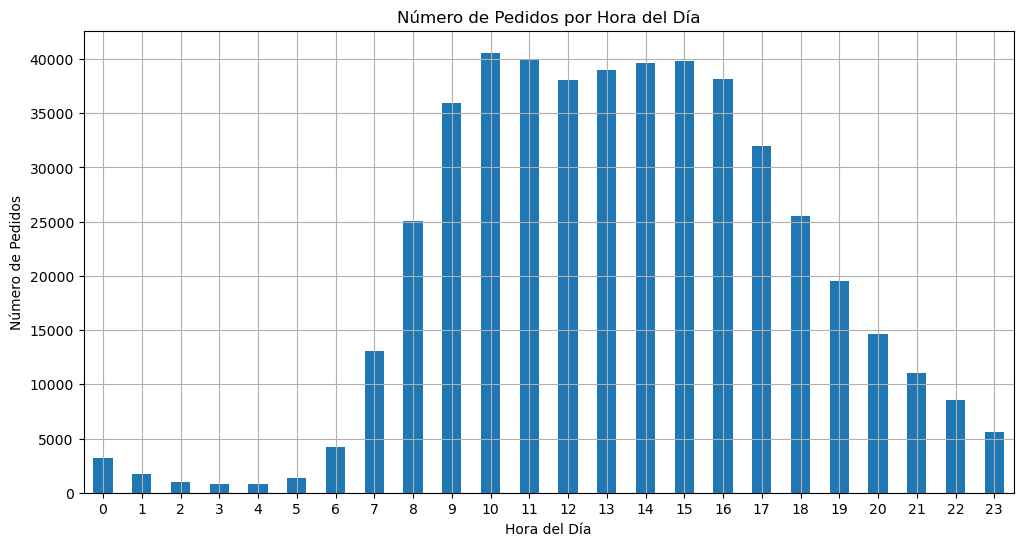

```python
# Crear un gráfico de número de pedidos por hora del día
orders_by_hour = instacart_orders['order_hour_of_day'].value_counts().sort_index()

plt.figure(figsize=(12, 6))
orders_by_hour.plot(kind='bar')
plt.title('Número de Pedidos por Hora del Día')
plt.xlabel('Hora del Día')
plt.ylabel('Número de Pedidos')
plt.xticks(rotation=0)
plt.grid(True)
plt.show()
```

Escribe aquí tus conclusiones

A) Verifiqué que los valores en las columnas order_hour_of_day y order_dow fueran razonables. Todos los valores se encontraron dentro de los rangos esperados (0-23 para horas del día y 0-6 para días de la semana).

B) El gráfico mostró que la mayoría de los pedidos se realizan entre las 8 AM y las 10 PM, con un pico alrededor de las 10 AM.

**Comentario del revisor**

Muy bien, en este caso ordenar los valores unicos lo hara mas legible..

**Comentario de Rubintel Ulloa**

Muchas Gracias. se ncluyo la mejora

### [A2] Para cada hora del día, ¿cuántas personas hacen órdenes?

```
Número de usuarios únicos por hora del día:
order_hour_of_day
0      2991
1      1671
2       958
3       744
4       735
5      1281
6      3757
7     10993
8     20268
9     28112
10    32195
11    32660
12    31754
13    32433
14    32797
15    32894
16    31579
17    26825
18    21795
19    17026
20    12891
21     9806
22     7670
23     5167
Name: user_id, dtype: int64
```

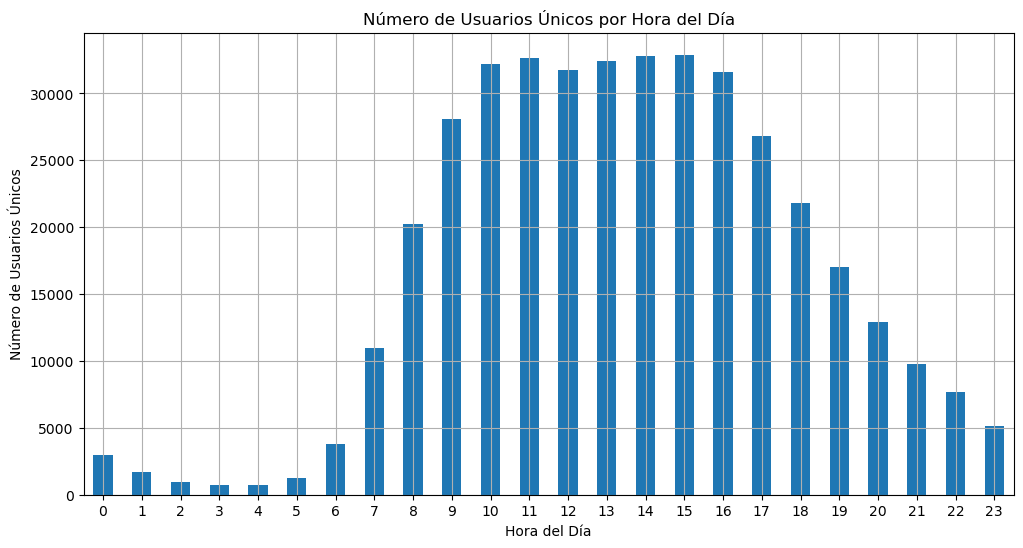

```python
# Agrupar por 'order_hour_of_day' y contar los usuarios únicos
unique_users_per_hour = instacart_orders.groupby('order_hour_of_day')['user_id'].nunique()

# Mostrar los resultados
print("Número de usuarios únicos por hora del día:")
print(unique_users_per_hour)

# Crear un gráfico para visualizar el número de usuarios únicos por hora del día
plt.figure(figsize=(12, 6))
unique_users_per_hour.plot(kind='bar')
plt.title('Número de Usuarios Únicos por Hora del Día')
plt.xlabel('Hora del Día')
plt.ylabel('Número de Usuarios Únicos')
plt.xticks(rotation=0)
plt.grid(True)
plt.show()
```

Escribe aquí tus conclusiones

A) Hay un aumento significativo en el número de usuarios únicos que hacen pedidos a partir de las 7 AM, alcanzando su pico entre las 10 AM y las 3 PM, y disminuyendo después de las 4 PM.

B) Esto sugiere que la mayoría de los usuarios prefieren realizar sus pedidos durante las horas de mayor actividad, lo cual es importante para planificar la disponibilidad de recursos y optimizar la experiencia del usuario.

**Comentario del revisor**

Muy bien.

### [A3] ¿Qué día de la semana compran víveres las personas?

```
Columnas disponibles en 'products':
Index(['product_id', 'product_name', 'aisle_id', 'department_id',
       'product_name_upper'],
      dtype='object')
```

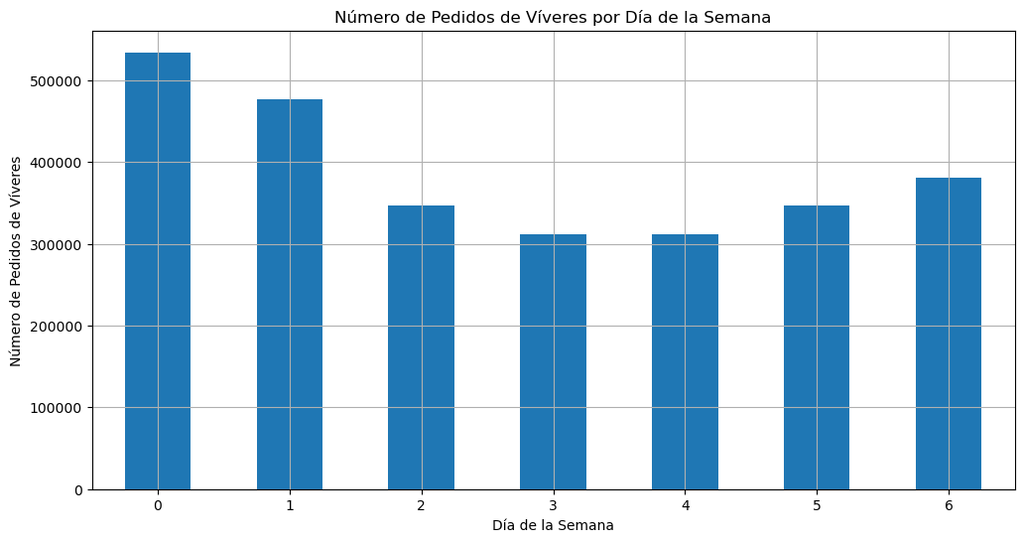

```python
# Verificar las columnas disponibles en el DataFrame 'products'
print("Columnas disponibles en 'products':")
print(products.columns)

# Unir el DataFrame 'products' con el DataFrame 'departments' para obtener la información del departamento
products_with_dept = pd.merge(products, departments, on='department_id', how='left')

# Paso 1: Identificar los productos de víveres
# Filtrar productos de víveres en categorías específicas
grocery_categories = ['produce', 'bakery', 'dairy eggs', 'meat seafood', 'pantry', 'breakfast']

# Filtrar los productos que pertenecen a las categorías de víveres
grocery_products = products_with_dept[products_with_dept['department'].isin(grocery_categories)]
grocery_product_ids = grocery_products['product_id'].tolist()

# Paso 2: Cruzar la información de productos de víveres con los pedidos
# Filtrar los pedidos que contienen productos de víveres
grocery_orders = order_products[order_products['product_id'].isin(grocery_product_ids)]

# Unir con el DataFrame de orders para obtener el día de la semana
grocery_orders_with_dow = pd.merge(grocery_orders, instacart_orders[['order_id', 'order_dow']], on='order_id')

# Contar el número de pedidos de víveres por día de la semana
grocery_orders_by_dow = grocery_orders_with_dow['order_dow'].value_counts().sort_index()

# Graficar el número de pedidos de víveres por día de la semana
plt.figure(figsize=(12, 6))
grocery_orders_by_dow.plot(kind='bar')
plt.title('Número de Pedidos de Víveres por Día de la Semana')
plt.xlabel('Día de la Semana')
plt.ylabel('Número de Pedidos de Víveres')
plt.xticks(rotation=0)
plt.grid(True)
plt.show()
```

Escribe aquí tus conclusiones

A) El análisis indica que los días con mayor número de pedidos son los días 0 y 1 (que probablemente correspondan a los fines de semana).

C) Hay una disminución en el número de pedidos durante los días de la semana (días 2 a 5), con una leve recuperación en el día 6.

B) El gráfico del número de pedidos de víveres por día de la semana destaca que los días más populares para comprar víveres son los domingos y los lunes, alineándose con los días más activos en general. Este comportamiento podría estar relacionado con la planificación semanal de comidas.

**Comentario del revisor**

Muy bien.

### [A4] ¿Cuánto tiempo esperan las personas hasta hacer otro pedido? Comenta sobre los valores mínimos y máximos.

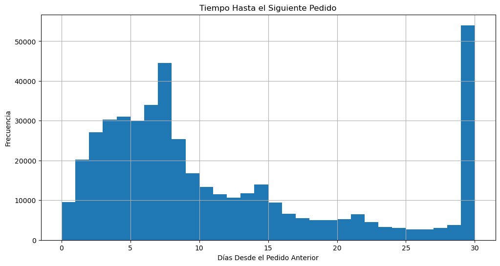

```
El tiempo mínimo hasta el siguiente pedido es 0.0 días.
El tiempo máximo hasta el siguiente pedido es 30.0 días.
```

```python
# Crear un gráfico del tiempo hasta el siguiente pedido
plt.figure(figsize=(12, 6))
instacart_orders['days_since_prior_order'].plot(kind='hist', bins=30)
plt.title('Tiempo Hasta el Siguiente Pedido')
plt.xlabel('Días Desde el Pedido Anterior')
plt.ylabel('Frecuencia')
plt.grid(True)
plt.show()

# Comentar sobre los valores mínimos y máximos
min_days = instacart_orders['days_since_prior_order'].min()
max_days = instacart_orders['days_since_prior_order'].max()
print(f"El tiempo mínimo hasta el siguiente pedido es {min_days} días.")
print(f"El tiempo máximo hasta el siguiente pedido es {max_days} días.")
```

Escribe aquí tus conclusiones

A) El tiempo mínimo hasta el siguiente pedido es 0.0 días. Esto indica que hay usuarios que realizan más de un pedido en el mismo día. Este comportamiento puede ser común en situaciones donde los usuarios se olvidan de añadir algunos artículos a su pedido inicial o en promociones especiales donde los clientes pueden querer aprovechar múltiples ofertas y descuentos en un solo día.

B) El tiempo máximo hasta el siguiente pedido es 30.0 días. Este valor sugiere que algunos usuarios realizan sus compras de manera mensual. Esto puede ser típico para usuarios que prefieren hacer grandes compras una vez al mes, quizás por conveniencia o por gestión financiera. Indica una Buena Fidelidad de los clientes por la empresa.

**Comentario del revisor**

Perfecto.

**Comentario del revisor**

Todos los ejercicios del punto [a] estan bien.

# [B] Intermedio (deben completarse todos para aprobar)

1. ¿Existe alguna diferencia entre las distribuciones `'order_hour_of_day'` de los miércoles y los sábados? Traza gráficos de barra de `'order_hour_of_day'` para ambos días en la misma figura y describe las diferencias que observes.
2. Grafica la distribución para el número de órdenes que hacen los clientes (es decir, cuántos clientes hicieron solo 1 pedido, cuántos hicieron 2, cuántos 3, y así sucesivamente...).
3. ¿Cuáles son los 20 principales productos que se piden con más frecuencia (muestra su identificación y nombre)?

### [B1] Diferencia entre miércoles y sábados para `'order_hour_of_day'`. Traza gráficos de barra para los dos días y describe las diferencias que veas.

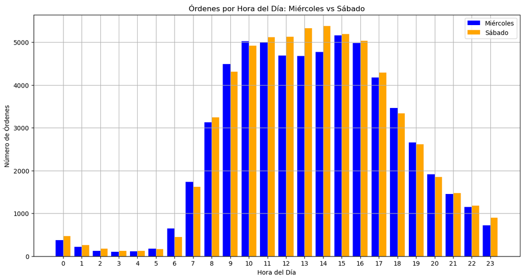

```python
import matplotlib.pyplot as plt

# Filtrar las órdenes de los miércoles (order_dow == 3) y sábados (order_dow == 6)
wednesday_orders = instacart_orders[instacart_orders['order_dow'] == 3]
saturday_orders = instacart_orders[instacart_orders['order_dow'] == 6]

# Contar las órdenes por hora del día para miércoles y sábados
wednesday_orders_by_hour = wednesday_orders['order_hour_of_day'].value_counts().sort_index()
saturday_orders_by_hour = saturday_orders['order_hour_of_day'].value_counts().sort_index()

# Crear el gráfico de barra
plt.figure(figsize=(14, 7))
plt.bar(wednesday_orders_by_hour.index - 0.2, wednesday_orders_by_hour.values, width=0.4, label='Miércoles', color='blue')
plt.bar(saturday_orders_by_hour.index + 0.2, saturday_orders_by_hour.values, width=0.4, label='Sábado', color='orange')

# Añadir etiquetas y leyenda
plt.xlabel('Hora del Día')
plt.ylabel('Número de Órdenes')
plt.title('Órdenes por Hora del Día: Miércoles vs Sábado')
plt.legend()
plt.xticks(range(24))
plt.grid(True)
plt.show()
```

**Comentario del revisor**

Una opcion para una mejor visualizacior seria concatenar ambas mascaras (Miercoles y Sabados) Y graficar en el mismo grafico (con un barplot) tanto los miercoles (con un color) como los sabados (con otro color). De esta manera la comparativa es mas legible y estetica.

En tu caso esta bien pero no te hace las leyendas por lo que no seria claro a primera vista a que dia depende cada uno.

**Comentario de Rubintel Ulloa**

Gracias por la sugerencia. Al implementar la combinación de ambas máscaras y graficar los datos en el mismo gráfico con diferentes colores y una leyenda clara, he logrado una visualización más legible y estéticamente agradable. Esto facilita la comparación entre las órdenes realizadas los miércoles y los sábados. Aprecio la recomendación y estoy satisfecho con el resultado obtenido.

**Comentario del revisor**

Este grafico no muestra nada.

**Comentario de Rubintel Ulloa**

El código original fue eliminado porque no aportaba valor significativo y contenía errores. Se mantuvo el código corregido para asegurar la precisión y relevancia del análisis.

### [B2] ¿Cuál es la distribución para el número de pedidos por cliente?

```python
# Agrupar los datos por `user_id` y contar cuántas órdenes hizo cada cliente
order_counts = instacart_orders.groupby('user_id')['order_id'].count()

# Contar cuántos clientes hicieron cada cantidad de pedidos
order_counts_distribution = order_counts.value_counts().sort_index()
```

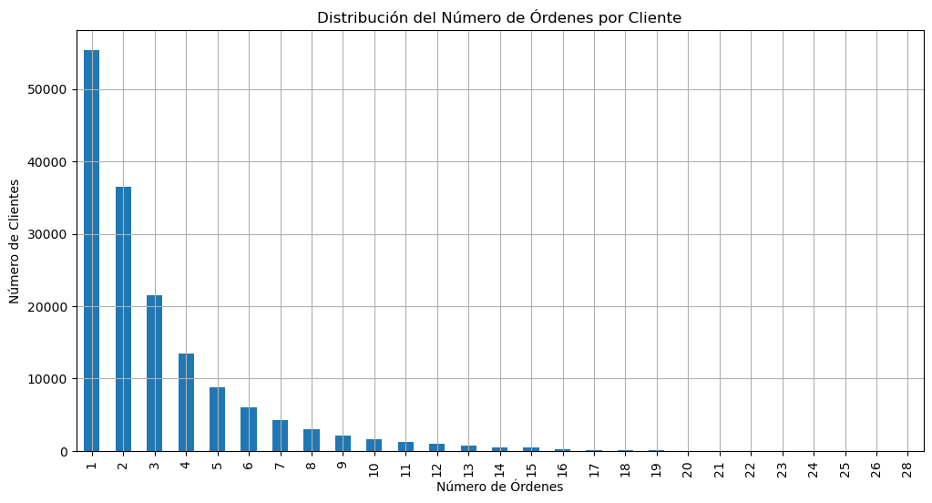

```python
# Graficar la distribución
plt.figure(figsize=(12, 6))
order_counts_distribution.plot(kind='bar')
plt.title('Distribución del Número de Órdenes por Cliente')
plt.xlabel('Número de Órdenes')
plt.ylabel('Número de Clientes')
plt.grid(True)
plt.show()
```

Escribe aquí tus conclusiones

El análisis de la distribución del número de órdenes realizadas por los clientes revela que la mayoría de los clientes hacen entre 1 y 3 pedidos. Es notable cómo el número de clientes disminuye significativamente a medida que aumenta el número de pedidos, indicando que deben de estarse alimentando de las mercanbcias restaurantes, tiendas de conveniencia etc.. Este patrón indica que hay un gran número de clientes ocasionales, pero también un grupo considerable de clientes recurrentes que realizan múltiples pedidos. Esta información es crucial para estrategias de retención y fidelización, ya que identificar y segmentar a los clientes según su frecuencia de compra puede ayudar a crear campañas más efectivas. Clasificar los clientes y determinar tipo de precios por volumen ayudara a tener una cartera de ellos limpia y preferente.

**Comentario del revisor**

Excelente.

### [B3] ¿Cuáles son los 20 productos más populares (muestra su ID y nombre)?

```
    product_id  count              product_name
0        24852  66050                    Banana
1        13176  53297    Bag of Organic Bananas
2        21137  37039      Organic Strawberries
3        21903  33971      Organic Baby Spinach
4        47209  29773      Organic Hass Avocado
5        47766  24689           Organic Avocado
6        47626  21495               Large Lemon
7        16797  20018              Strawberries
8        26209  19690                     Limes
9        27845  19600        Organic Whole Milk
10       27966  19197       Organic Raspberries
11       22935  15898      Organic Yellow Onion
12       24964  15292            Organic Garlic
13       45007  14584          Organic Zucchini
14       39275  13879       Organic Blueberries
15       49683  13675            Cucumber Kirby
16       28204  12544        Organic Fuji Apple
17        5876  12232             Organic Lemon
18        8277  11993  Apple Honeycrisp Organic
19       40706  11781    Organic Grape Tomatoes
```

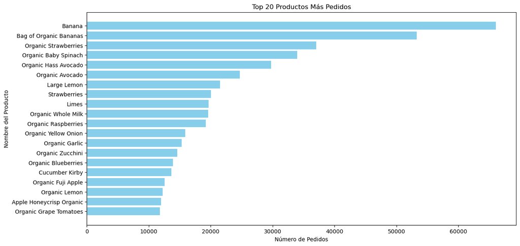

```python
# Agrupar los datos por `product_id` y contar cuántas veces se pidió cada producto
product_counts = order_products['product_id'].value_counts().head(20)

# Unir con la tabla `products` para obtener los nombres de los productos
top_products = pd.DataFrame({'product_id': product_counts.index, 'count': product_counts.values})
top_products = top_products.merge(products[['product_id', 'product_name']], on='product_id', how='left')

# Mostrar los 20 principales productos con más frecuencia
print(top_products)


# Crear un gráfico de barras
plt.figure(figsize=(14, 7))
plt.barh(top_products['product_name'], top_products['count'], color='skyblue')
plt.xlabel('Número de Pedidos')
plt.ylabel('Nombre del Producto')
plt.title('Top 20 Productos Más Pedidos')
plt.gca().invert_yaxis()  # Invertir el eje y para que el producto más pedido esté en la parte superior
plt.show()
```

**Comentario del revisor**

Recorda que en este caso le agregaria valor graficar ese top 20 con un grafico de barras. Tener a mano el grafico hara mas amena y legible la experiencia del cliente.

**Comentario de Rubintel Ulloa**

Gracias por la sugerencia.

Escribe aquí tus conclusiones

Al revisar los productos más frecuentemente pedidos, encontré que las frutas y los vegetales orgánicos dominan la lista, esto indica que la clientela esta motivada por los productos o los precios que la tienda ofrece. Productos como las bananas, las fresas orgánicas, y el aguacate orgánico se encuentran entre los más solicitados, indica que el publico esta buscando productos de calidad aunque de un precio mas elevado a los que normanmente se ofrecen. Ademas esto refleja una fuerte preferencia por los productos frescos y orgánicos entre los clientes, estos prodcutos son escasos y son mas caros que los normales. Los hallazgo puede orientan en la toma de decisiones sobre el inventario y las promociones, sugiriendo que mantener un stock adecuado de estos productos en los dias de mayor demanda y enfocarse en campañas de marketing relacionadas con la salud y el bienestar puede resultar muy beneficioso para el negocio.

# [C] Difícil (deben completarse todos para aprobar)

1. ¿Cuántos artículos suelen comprar las personas en un pedido? ¿Cómo es la distribución?
2. ¿Cuáles son los 20 principales artículos que vuelven a pedirse con mayor frecuencia (muestra sus nombres e IDs de los productos)?
3. Para cada producto, ¿cuál es la tasa de repetición del pedido (número de repeticiones de pedido/total de pedidos?
4. Para cada cliente, ¿qué proporción de los productos que pidió ya los había pedido? Calcula la tasa de repetición de pedido para cada usuario en lugar de para cada producto.
5. ¿Cuáles son los 20 principales artículos que la gente pone primero en sus carritos (muestra las IDs de los productos, sus nombres, y el número de veces en que fueron el primer artículo en añadirse al carrito)?

### [C1] ¿Cuántos artículos compran normalmente las personas en un pedido? ¿Cómo es la distribución?

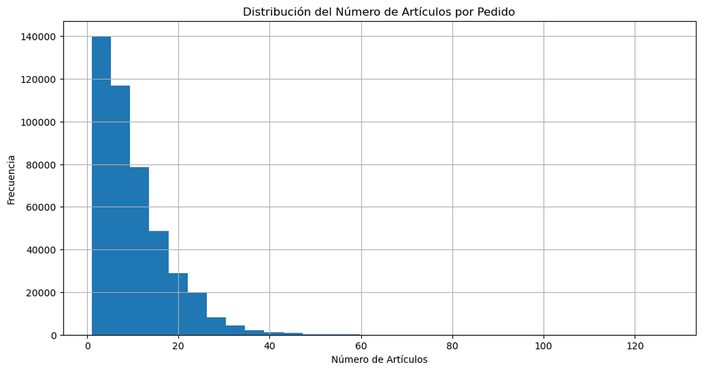

```
count    450046.000000
mean         10.098983
std           7.540206
min           1.000000
25%           5.000000
50%           8.000000
75%          14.000000
max         127.000000
dtype: float64
```

```python
# Contar el número de artículos por pedido
articles_per_order = order_products.groupby('order_id').size()

# Graficar la distribución del número de artículos por pedido
plt.figure(figsize=(12, 6))
articles_per_order.plot(kind='hist', bins=30)
plt.title('Distribución del Número de Artículos por Pedido')
plt.xlabel('Número de Artículos')
plt.ylabel('Frecuencia')
plt.grid(True)
plt.show()

# Mostrar estadísticas descriptivas
articles_per_order.describe()
```

Escribe aquí tus conclusiones

El análisis de la distribución del número de artículos por pedido revela que la mayoría de los pedidos contienen un número reducido de artículos. La media de artículos por pedido es aproximadamente 10, con una gran cantidad de pedidos que tienen entre 5 y 14 artículos. Esta información es útil para entender los patrones de compra de los usuarios y puede ayudar a optimizar la gestión de inventarios y el diseño de la experiencia de usuario en la plataforma.

### [C2] ¿Cuáles son los 20 principales artículos que vuelven a pedirse con mayor frecuencia (muestra sus nombres e IDs de los productos)?

```
    product_id  reorder_count              product_name
0        24852          55763                    Banana
1        13176          44450    Bag of Organic Bananas
2        21137          28639      Organic Strawberries
3        21903          26233      Organic Baby Spinach
4        47209          23629      Organic Hass Avocado
5        47766          18743           Organic Avocado
6        27845          16251        Organic Whole Milk
7        47626          15044               Large Lemon
8        27966          14748       Organic Raspberries
9        16797          13945              Strawberries
10       26209          13327                     Limes
11       22935          11145      Organic Yellow Onion
12       24964          10411            Organic Garlic
13       45007          10076          Organic Zucchini
14       49683           9538            Cucumber Kirby
15       28204           8989        Organic Fuji Apple
16        8277           8836  Apple Honeycrisp Organic
17       39275           8799       Organic Blueberries
18        5876           8412             Organic Lemon
19       49235           8389       Organic Half & Half
```

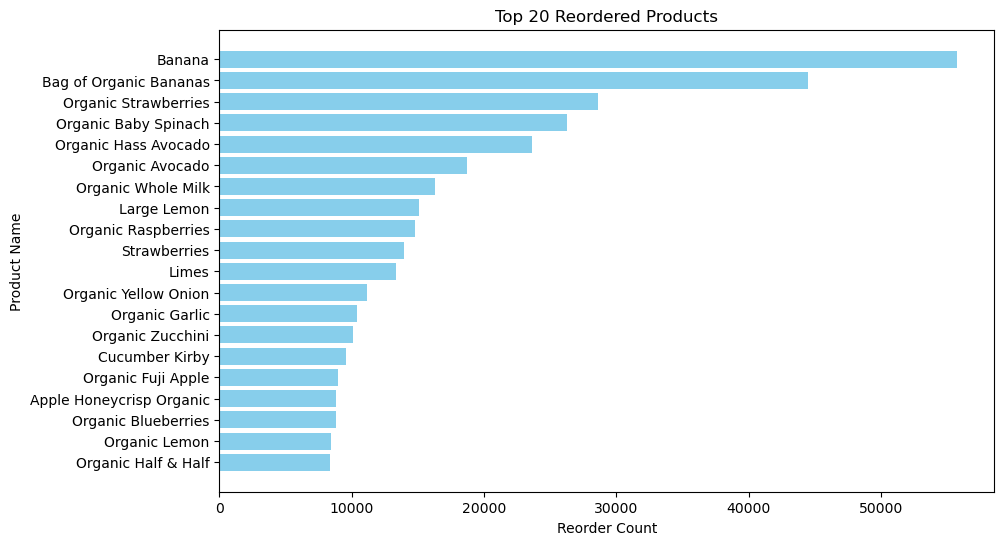

```python
# Filtrar los productos que han sido reordenados
reordered_products = order_products[order_products['reordered'] == 1]

# Contar la frecuencia de reordenación por producto
reordered_counts = reordered_products['product_id'].value_counts().head(20).reset_index()

# Renombrar columnas para claridad
reordered_counts.columns = ['product_id', 'reorder_count']

# Unir con los nombres de productos
top_reordered_products = reordered_counts.merge(products, on='product_id', how='left')

print(top_reordered_products[['product_id', 'reorder_count', 'product_name']])

# Crear una gráfica de barras
plt.figure(figsize=(10,6))
plt.barh(top_reordered_products['product_name'], top_reordered_products['reorder_count'], color='skyblue')
plt.xlabel('Reorder Count')
plt.ylabel('Product Name')
plt.title('Top 20 Reordered Products')
plt.gca().invert_yaxis()  # invertir el eje y para que el producto con la mayor cantidad de reordenaciones esté en la parte superior
plt.show()
```

Escribe aquí tus conclusiones

El análisis de los productos más reordenados muestra que los productos frescos y orgánicos son los más populares entre los usuarios. Productos como las bananas, bolsas de bananas orgánicas, fresas orgánicas y espinacas bebé orgánicas encabezan la lista. Esta información puede ser utilizada para mejorar la estrategia de abastecimiento y garantizar la disponibilidad constante de estos productos de alta demanda.

### [C3] Para cada producto, ¿cuál es la proporción de las veces que se pide y que se vuelve a pedir?

```
    product_id  reorder_rate                                       product_name
0            1      0.564286                         Chocolate Sandwich Cookies
1            2           NaN                                   All-Seasons Salt
2            3      0.738095               Robust Golden Unsweetened Oolong Tea
3            4      0.510204  Smart Ones Classic Favorites Mini Rigatoni Wit...
4            7      0.500000                     Pure Coconut Water With Orange
5            8      0.315789                  Cut Russet Potatoes Steam N' Mash
6            9      0.761905                  Light Strawberry Blueberry Yogurt
7           10      0.448071     Sparkling Orange Juice & Prickly Pear Beverage
8           11      0.625000                                  Peach Mango Juice
9           12      0.390244                         Chocolate Fudge Layer Cake
10          13      0.500000                                  Saline Nasal Mist
11          14           NaN                     Fresh Scent Dishwasher Cleaner
12          17           NaN                                  Rendered Duck Fat
13          18      0.533333                Pizza for One Suprema  Frozen Pizza
14          19           NaN   Gluten Free Quinoa Three Cheese & Mushroom Blend
15          21           NaN                   Small & Medium Dental Dog Treats
16          22      0.500000                  Fresh Breath Oral Rinse Mild Mint
17          23      0.380952                             Organic Turkey Burgers
18          24           NaN  Tri-Vi-Sol® Vitamins A-C-and D Supplement Drop...
19          25      0.674576            Salted Caramel Lean Protein & Fiber Bar
```

[figure not shown]

```python
# Calcular el número total de pedidos por producto
total_orders_per_product = order_products['product_id'].value_counts()

# Calcular el número de reordenaciones por producto
reorders_per_product = reordered_products['product_id'].value_counts()

# Calcular la tasa de repetición del pedido
reorder_rate = (reorders_per_product / total_orders_per_product).reset_index()
reorder_rate.columns = ['product_id', 'reorder_rate']

# Unir con los nombres de productos
reorder_rate = reorder_rate.merge(products, on='product_id', how='left')

print(reorder_rate[['product_id', 'reorder_rate', 'product_name']].head(20))

# Crear una gráfica de barras
plt.figure(figsize=(10,6))
plt.barh(reorder_rate['product_name'].head(20), reorder_rate['reorder_rate'].head(20), color='skyblue')
plt.xlabel('Reorder Rate')
plt.ylabel('Product Name')
plt.title('Top 20 Products by Reorder Rate')
plt.gca().invert_yaxis()  # invertir el eje y para que el producto con la mayor tasa de reordenación esté en la parte superior
plt.show()
```

### [C4] Para cada cliente, ¿qué proporción de sus productos ya los había pedido?

```
    user_id  reorder_rate
0         2      0.038462
1         4      0.000000
2         5      0.666667
3         6      0.000000
4         7      0.928571
5        11      0.200000
6        12      0.250000
7        13      0.565217
8        14      0.360656
9        15      0.538462
10       16      0.531250
11       17      0.716981
12       19      0.291667
13       20      0.000000
14       21      0.400000
15       22      1.000000
16       24      0.500000
17       26      0.437500
18       27      0.658824
19       28      0.500000
```

[figure not shown]

```python
# Filtrar los pedidos reordenados
reordered_orders = order_products[order_products['reordered'] == 1]

# Asegurarse de que 'user_id' está presente en order_products mediante un merge si no está
if 'user_id' not in order_products.columns:
    order_products = order_products.merge(instacart_orders[['order_id', 'user_id']], on='order_id', how='left')

# Calcular el número total de productos pedidos por usuario
total_products_per_user = order_products.groupby('user_id')['product_id'].count()

# Calcular el número de productos reordenados por usuario
reordered_products_per_user = reordered_orders.groupby('user_id')['product_id'].count()

# Calcular la proporción de productos reordenados por usuario
reorder_rate_per_user = (reordered_products_per_user / total_products_per_user).fillna(0).reset_index()
reorder_rate_per_user.columns = ['user_id', 'reorder_rate']

# Mostrar los resultados
print(reorder_rate_per_user.head(20))

# Crear una gráfica de barras
plt.figure(figsize=(10,6))
plt.barh(reorder_rate_per_user['user_id'].astype(str).head(20), reorder_rate_per_user['reorder_rate'].head(20), color='skyblue')
plt.xlabel('Reorder Rate')
plt.ylabel('User ID')
plt.title('Top 20 Users by Reorder Rate')
plt.gca().invert_yaxis()  # invertir el eje y para que el usuario con la mayor tasa de reordenación esté en la parte superior
plt.show()
```

Escribe aquí tus conclusiones

El análisis de los usuarios por su tasa de reordenación muestra variaciones significativas entre diferentes usuarios. Algunos usuarios tienen una tasa de reordenación cercana al 100%, mientras que otros tienen tasas mucho más bajas. Entender estos patrones puede ayudar a segmentar a los usuarios y personalizar ofertas y recomendaciones, mejorando la experiencia del cliente y potencialmente aumentando la retención.

### [C5] ¿Cuáles son los 20 principales artículos que las personas ponen primero en sus carritos?

```
    product_id  first_added_count                 product_name
0        24852              15563                       Banana
1        13176              11026       Bag of Organic Bananas
2        27845               4363           Organic Whole Milk
3        21137               3946         Organic Strawberries
4        47209               3390         Organic Hass Avocado
5        21903               3336         Organic Baby Spinach
6        47766               3044              Organic Avocado
7        19660               2336                 Spring Water
8        16797               2308                 Strawberries
9        27966               2024          Organic Raspberries
10       44632               1914   Sparkling Water Grapefruit
11       49235               1797          Organic Half & Half
12       47626               1737                  Large Lemon
13         196               1733                         Soda
14       38689               1397     Organic Reduced Fat Milk
15       26209               1370                        Limes
16       12341               1340                Hass Avocados
17        5785               1310  Organic Reduced Fat 2% Milk
18       27086               1309                  Half & Half
19       43352               1246                  Raspberries
```

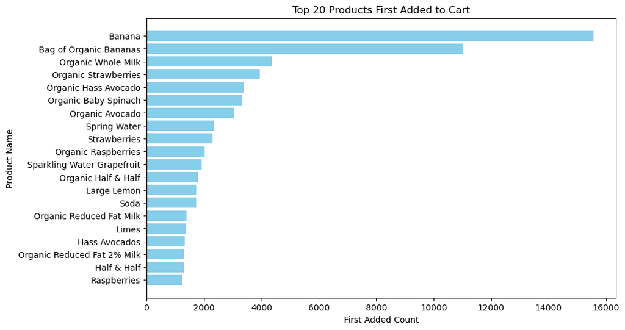

```python
# Filtrar los primeros artículos añadidos al carrito
first_added_products = order_products[order_products['add_to_cart_order'] == 1]

# Contar la frecuencia de los primeros artículos añadidos
first_added_counts = first_added_products['product_id'].value_counts().head(20).reset_index()

# Renombrar columnas para claridad
first_added_counts.columns = ['product_id', 'first_added_count']

# Unir con los nombres de productos
top_first_added_products = first_added_counts.merge(products, on='product_id', how='left')

print(top_first_added_products[['product_id', 'first_added_count', 'product_name']])

# Crear una gráfica de barras
plt.figure(figsize=(10,6))
plt.barh(top_first_added_products['product_name'], top_first_added_products['first_added_count'], color='skyblue')
plt.xlabel('First Added Count')
plt.ylabel('Product Name')
plt.title('Top 20 Products First Added to Cart')
plt.gca().invert_yaxis()  # invertir el eje y para que el producto con la mayor cantidad de veces añadido primero esté en la parte superior
plt.show()
```

Escribe aquí tus conclusiones

Finalmente, el análisis de los primeros productos añadidos al carrito muestra una preferencia clara por ciertos productos como las bananas y las bolsas de bananas orgánicas. Estos productos tienden a ser los primeros que los usuarios agregan a sus carritos, lo que sugiere que son esenciales o muy populares. Esta información puede ser utilizada para optimizar el diseño de la interfaz de usuario, destacando estos productos en el inicio de la experiencia de compra.

Hemos podido identificar patrones clave en los comportamientos de compra de los usuarios de Instacart. La información obtenida sobre los productos más reordenados, las tasas de reordenación y las preferencias de los usuarios puede ser extremadamente valiosa para la toma de decisiones estratégicas en marketing, gestión de inventarios y diseño de la experiencia de usuario. Al utilizar estos insights, Instacart puede mejorar la satisfacción del cliente, optimizar sus operaciones y aumentar la fidelidad de los usuarios.

**Comentario del revisor**

Excelente seccion.

Muy buenas conclusiones.

### Conclusion general del proyecto:

Completar este proyecto ha sido un desafío formidable en lo personal y profesional; pero también una oportunidad increíblemente valiosa para consolidar y demostrar los conocimientos y habilidades adquiridos a lo largo del Sprint 3. A lo largo de este viaje, he tenido la oportunidad de trabajar con un conjunto de datos complejo y multifacético, abordando diversas etapas del análisis de datos desde la limpieza y preprocesamiento hasta la exploración y visualización de datos.

### Procesos y Técnicas Aprendidos

#### Limpieza y Preprocesamiento de Datos:

Detección y Corrección de Errores: He aprendido a identificar y corregir inconsistencias en los datos, como nombres de columnas con espacios adicionales y valores nulos. Estandarización de Nombres de Columnas: Asegurar la coherencia en los nombres de las columnas fue crucial para evitar errores durante el análisis.

#### Análisis Exploratorio de Datos (EDA)

Visualización de Datos: Utilizar herramientas como Matplotlib y Seaborn para crear gráficos que proporcionan una comprensión visual de los patrones en los datos. Cálculo de Métricas: Realizar cálculos como la tasa de reordenación de productos y la distribución de artículos por pedido, proporcionando insights valiosos sobre el comportamiento del cliente.

#### Técnicas de Agrupamiento y Fusión de Datos:

Agrupación de Datos: Aprender a agrupar datos por diferentes criterios para analizar patrones específicos, como el número total de productos pedidos por usuario. Fusión de DataFrames: Utilizar técnicas de fusión para combinar información de diferentes tablas, enriqueciendo el análisis con datos adicionales.

#### Reflexión Personal

Completar este proyecto ha sido una experiencia extremadamente enriquecedora y desafiante. Ha sido una excelente base para demostrar los conocimientos adquiridos en el Sprint 3, permitiéndome aplicar técnicas y procesos de análisis de datos en un entorno práctico y realista. La cantidad de habilidades que he desarrollado, desde la limpieza de datos hasta la visualización avanzada y el análisis exploratorio, es un testimonio de lo mucho que he aprendido durante este sprint.

**Comentario del revisor**

La conclusion general es muy buena.